# Seminar 4 - løsningsforslag

Author

Mikko Moilanen

Published

October 28, 2024

## Oppgave a)

Gertruds nyttefunksjon er gitt ved $u=c^{1-\sigma}l^{\sigma}$. Hennes arbeidsfri inntekt ($m$) er 100 (i ti-tall kroner), timelønna er 10 og hun kan maksimalt jobbe 60 timer per uke ($l_0=60$). Når hun er frisk er hennes sykdomsindeks $\sigma=2/7$.La oss anta at det i utgangspunktet ikke finnes noen sykelønnsordning. Hva er hennes optimale tilpasning av arbeidstid og konsum når hun er frisk? Vis matematisk og grafisk.

### Problemstilling

Vi ønsker å maksimere Gertruds nyttefunksjon som er gitt ved:

$$U = c^{5/7} \cdot l^{2/7}$$

under bibetingelsen:

$$c = 700 - 10l$$
hvor $U$ er nytte, $c$ er konsum, og $l$ er fritid.

### Løsning ved Bruk av Lagrange-multiplikatorer

1. **Formuler Lagrange-funksjonen**

$$\mathcal{L}(c, l, \lambda) = c^{5/7} \cdot l^{2/7} + \lambda \cdot (700 - 10l - c)$$

2. **Førsteordensbetingelsene**

Vi beregner de partielle deriverte av $\mathcal{L}$med hensyn til $c$, $l$, og $\lambda$, og setter hver av dem lik null for å finne stasjonærpunktene:

$$\frac{\partial \mathcal{L}}{\partial c} = \frac{5}{7}c^{-2/7}l^{2/7} - \lambda = 0$$

$$\frac{\partial \mathcal{L}}{\partial l} = \frac{2}{7}c^{5/7}l^{-5/7} - 10\lambda = 0$$
$$\frac{\partial \mathcal{L}}{\partial \lambda} = 700 - 10l - c = 0$$

3. **Løs Ligningssystemet** Vi omarrangerer de to første førsteordensbetingelsene:

$$\frac{5}{7}c^{-2/7}l^{2/7}=\lambda$$
$$\frac{2}{7}c^{5/7}l^{-5/7} = 10\lambda$$
Vi kan nå “dele” (egentlig krysssmultipliserer vi) den første ligning med den andre Vi får
$$\frac{5}{7}\cdot\frac{7}{2}c^{-2/7-5/7}l^{2/7+5/7}=\frac{1}{10}$$
$$\frac{5}{2}c^{-1}l^{1}=\frac{1}{10}$$
$$\frac{5l}{2c}=\frac{1}{10}$$
$$50l=2c => c=25l$$
Vi setter dette i budsjettbetingelsen for $c$
$$25l=700-10l$$
$$l=20$$
Vi setter dette uttrykket inn for $l$ i $c=25l$ og får at $c=500$. Gertrud kan maksimalt jobbe 60 timer per uke ($l_0=60$), så arbeidstiden som maksimerer hennes nytte er da $60-20=40$ timer.

### Grafisk løsning

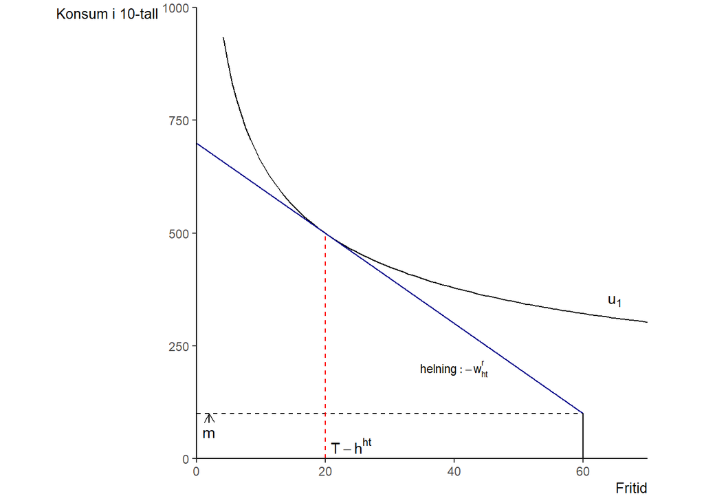

```r
  # Last inn de nødvendige pakkene
  library(ggplot2)
  library(grid)  # For ekstra funksjoner som 'arrow'
# Oppretter en sekvens og lagre den i l_1
  l_1 <- seq(0, 60, by = .01)  # l_1 representerer fritid, går fra 0 til 60

  # Konverterer sekvensen til en data.frame
  df <- data.frame(l_1)  # Dette gjør det enklere å håndtere i ggplot

  # Forbereder en ggplot-graf med definerte estetiske verdier og navn på aksene
  axes_1 <- ggplot(df, aes(l_1)) +  # Plottet basert på 'l_1' (fritid)
    labs(x="Fritid", y="Konsum i 10-tall") +  # Merker aksene
    theme(
      axis.title = element_text(size = 10),  # Tilpasser størrelsen på aksen titlene
      plot.title = element_text(size = 10),  # Tilpasser størrelsen på plottets tittel
      panel.background = element_blank(),  # Fjern bakgrunnen
      axis.line = element_line(colour = "black"),  # Gjør akselinjene svarte
      axis.title.x = element_text(hjust = 1),  # Justering av x-akse tittelen
      axis.title.y = element_text(angle = 0, vjust = 1, hjust=1)  # Justering av y-akse tittelen
    ) +
    #coord_fixed(ratio = 1) +  # Holder forholdet mellom x- og y-aksene konstant
    scale_x_continuous(limits = c(0, 70), expand = c(0, 0)) +  # Definerer grensene for x-aksen
    scale_y_continuous(limits = c(0, 1000), expand = c(0, 0)) +  # Definerer grensene for y-aksen
    coord_fixed(ratio = (70 - 0) / (1000 - 0))  # Sørger for at akselinjene møtes i (0,0)
# Definerer indifferenskurver (Cobb-Douglas nyttefunksjoner) i optimale punkter i oppgavene a), b) og c)
  # vi angir noen indifferenskurver
  I_0 <- function(l_1) ((140.11310323534026984156338498747)/(l_1^0.6))^(1/0.4)# maksimalt nyttenivå (som funksjon av c) når Gertrud er LITT SYK (vi setter inn de optimale verdiene av c og l som vi har funnet ved hjelp
  # av Lagrange for å finne verdien for U)  og kompensasjonsgraden er 100%
  I_2 <- function(l_1) ((199.323531563868829097371190248)/(l_1^0.28571428571428571428571428571429))^(1/0.71428571428571428571428571428571)  # maksimalt nyttenivå (som funksjon av c) når Gertrud er FRISK (vi setter inn de #optimale verdiene av c og l)
  I_3 <- function(l_1) ((98.990004813225681474599658982193)/(l_1^0.6))^(1/0.4) # # maksimalt nyttenivå (som funksjon av c) når Gertrud er LITT SYK (vi setter inn de optimale verdiene av c og l som vi har funnet ved hjelp av #Lagrange for å finne verdien for U) og kompensasjonsgraden er 25%

  # Definerer budsjettlinjer med og uten sykepenger
  wr <- function(l_1) {
    return(700 - 10 * l_1)  # Budsjettlinje uten sykepenger
  }
  wrsp_0 <- function(l_1) {
    return(500 - 0*10* l_1)  # Budsjettlinje med 100% sykepenger
  }

  wrsp_1 <- function(l_1) {
    return(650 - 0.75*10* l_1)  # Budsjettlinje med 25% sykepenger
  }
  # Tegner den optimale tilpasningen uten sykepenger
  figur_1 <- axes_1 +  # Basen av plottet
#    stat_function(df,
#                  fun=I_0,
#                  mapping = aes()
#    )+
   # stat_function(df,
    #              fun=I_1,
     #             mapping = aes()
  #  )+
    stat_function(df,
                  fun=I_2,
                  mapping = aes()
    )+
#    stat_function(df,
#                  fun=I_3,
#                  mapping = aes()
#    )+
    annotate("text",
             x=65,
             y=350,
             label=expression(u[1]))+
    geom_segment(aes(x = 0, y = wr(0), xend = 60, yend = wr(60)), color="darkblue") +  # Tegner budsjettlinje
    annotate("text", x=40,y=200, size = 3,
             label= expression(helning: -w[ht]^{r}))+
  #  geom_segment(aes(x = 20, y = wrsp_0(20), xend = 60, yend = wrsp_0(60)), color="blue") +
  #  geom_segment(aes(x = 20, y = wrsp_1(20), xend = 60, yend = wrsp_1(60)), color="blue") +
  #  annotate("text",x=40,y=430, size = 3,
   #          label= expression(helning: -(w-k*w)))+
    geom_segment(aes(x=60, y=0, xend=60, yend=100))+
   # geom_segment(aes(x=60, y=100, xend=60, yend=500), color="darkgray", linewidth=2)+
   # geom_segment(aes(x=60, y=100, xend=60, yend=200), color="black", linewidth=2)+
    geom_segment(aes(x=0, y=100, xend=60, yend=100), linetype="dashed")+
    annotate("text",x=2,y=60,
             label="m")+
    geom_segment(aes(x=2, y=80, xend=2, yend=100),
                 arrow = arrow(length = unit(0.25, "cm")))+
    geom_segment(aes(x=20, y=0, xend=20, yend=500), linetype="dashed", color="red")+
    annotate("text",x=24,y=30,
             label=expression(T-h^{ht}))
figur_1
```

## Oppgave b)

Vi antar at det innføres et sykepengesystem med 100 % kompensasjonsgrad. Gertrud blir nå litt syk, hennes sykdomsindeks øker da til 0.6. Hva blir hennes tilpasning nå? Vis grafisk.

Grafisk løsning

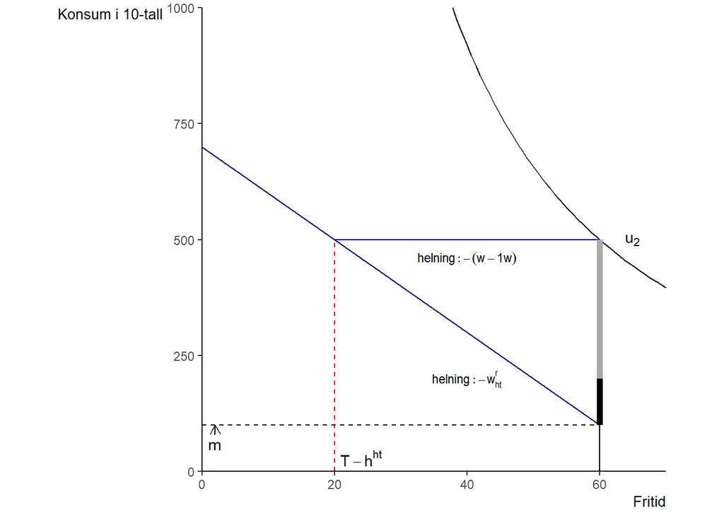

```r
  # Last inn nødvendige biblioteker
  library(ggplot2)
  library(grid)  # For ekstra funksjoner som 'arrow'
  # Definerer budsjettlinjer med og uten skatt
  wr <- function(l_1) {
    return(700 - 10 * l_1)  # Budsjettlinje uten sykepenger
  }
  wrsp_0 <- function(l_1) {
    return(500 - 0*10* l_1)  # Budsjettlinje med 100% sykepenger
  }

  wrsp_1 <- function(l_1) {
    return(650 - 0.75*10* l_1)  # Budsjettlinje med 25% sykepenger
  }
  # Tegner sammenligning av indifferenskurver og budsjettbegrensninger
  figur_2 <- axes_1 +  # Basen av plottet
    stat_function(df,
                  fun=I_0,
                  mapping = aes()
    )+
   # stat_function(df,
    #              fun=I_1,
     #             mapping = aes()
  #  )+
  #  stat_function(df,
 #                 fun=I_2,
 #                 mapping = aes()
 #   )+
 #   stat_function(df,
 #                 fun=I_3,
 #                 mapping = aes()
 #   )+
    annotate("text",
             x=65,
             y=500,
             label=expression(u[2]))+
    geom_segment(aes(x = 0, y = wr(0), xend = 60, yend = wr(60)), color="darkblue") +  # Tegner budsjettlinje
    annotate("text", x=40,y=200, size = 3,
             label= expression(helning: -w[ht]^{r}))+
    geom_segment(aes(x = 20, y = wrsp_0(20), xend = 60, yend = wrsp_0(60)), color="blue") +
  #  geom_segment(aes(x = 20, y = wrsp_1(20), xend = 60, yend = wrsp_1(60)), color="blue") +
    annotate("text",x=40,y=460, size = 3,
             label= expression(helning: -(w-1*w)))+
    geom_segment(aes(x=60, y=0, xend=60, yend=100))+
    geom_segment(aes(x=60, y=100, xend=60, yend=500), color="darkgray", linewidth=2)+
    geom_segment(aes(x=60, y=100, xend=60, yend=200), color="black", linewidth=2)+
    geom_segment(aes(x=0, y=100, xend=60, yend=100), linetype="dashed")+
    annotate("text",x=2,y=60,
             label="m")+
    geom_segment(aes(x=2, y=80, xend=2, yend=100),
                 arrow = arrow(length = unit(0.25, "cm")))+
    geom_segment(aes(x=20, y=0, xend=20, yend=500), linetype="dashed", color="red")+
    annotate("text",x=24,y=30,
             label=expression(T-h^{ht}))
figur_2
```

## Oppgave c)

La oss anta at sykepengeordningen blir endret slik at kompensasjonsgraden blir 25 %. Gertrud er like syk som i oppgave b). Hun mister ikke kompensasjon dersom hun jobber. Hvordan vil Gertrud tilpasse seg og hva vil hennes sykefraværsprosent være? Hvordan påvirker reduseringen av kompensasjonsgrad Gertruds tilpasning? Vis matematisk og grafisk.

### Matematisk løsning

Vi må først finne ut helningen til budsjettbetingelsen med den nye kompensasjonsgraden: Hvis du har et punkt gjennom hvilket en linje passerer, og du kjenner linjens helning, kan du finne ligningen for linjen ved å bruke punkt-helning formelen for en linje. I dette tilfelle, siden man har punktet $(500, 20)$ og en helning på $-7.5$, vil du kunne bruke denne informasjonen som følger:

Formelen for en linje i punkt-helning form er:

$$c - c_1 = r(l - l_1)$$

hvor $r$ er helningen, og $(x_1, y_1)$ er punktet linjen går gjennom.

Setter vi inn verdiene du har:

1. $r = -7.5$ (gitt helning)
2. $l_1 = 20$ og $c_1 = 500$ (koordinatene til punktet)

Setter vi inn disse verdiene i ligningen, får vi:

$$c - 500 = -7.5(l - 20)$$

For å gjøre dette til en mer standard lineær formel, kan vi omorganisere den:

$$c = -7.5l + 7.5*20 + 500$$
$$c = -7.5l + 150 + 500$$
$$c = -7.5l + 650$$

Så, den lineære ligningen som representerer linjen i et (c, l)-diagram er:

$$c = 650 -7.5l$$

For å finne arbeidstiden som maksimerer nytten kan vi bruke Lagrange: Vi ønsker å maksimere nyttefunksjonen $U = c^0.4 * l^0.6$ gitt budsjettbetingelsen $c = 650 - 7.5l$.

1. **Formuler Lagrange-funksjonen**: Lagrangianen (L) er en kombinasjon av målfunksjonen (i dette tilfellet, nyttefunksjonen) og begrensningen (budsjettlinjen), justert av en Lagrange-multiplikator (λ). Vi tilføyer produktet av Lagrange-multiplikatoren og begrensningen til målfunksjonen.

   $$L = c^{0.4} l^{0.6} + λ(650 - 7.5l - c)$$

## Førsteordensbetingelser

$$\frac{\partial \mathcal{L}}{\partial c}=0.4c^{-0.6} \cdot l^{0.6} - \lambda = 0 \quad \Longrightarrow \quad \lambda = 0.4c^{-0.6} l^{0.6}$$

$$\frac{\partial \mathcal{L}}{\partial l}=0.6c^{0.4}l^{-0.4} - 7.5\lambda = 0$$

$$\frac{\partial \mathcal{L}}{\partial \lambda}=650 - 7.5l - c = 0$$

3. **Løs Ligningssystemet** Vi omarrangerer de to første førsteordensbetingelsene
   $$\lambda = 0.4c^{-0.6} l^{0.6}$$
   $$7.5\lambda = 0.6 c^{0.4} l^{-0.4}$$
   Vi kan nå “dele” (egentlig krysssmultipliserer vi) den første ligning med den andre Vi får
   $$\frac{0.4}{0.6}\cdot c^{-0.6-0.4}l^{0.6+0.4}=\frac{1}{7.5}$$
   $$\frac{2}{3}c^{-1}l^{1}=\frac{1}{7.5}$$
   $$\frac{2l}{3c}=\frac{1}{7.5}$$
   $$15l=3c => c=5l$$
   Vi setter dette i budsjettbetingelsen for $c$
   $$5l=650-7.5l$$
   $$l=52$$
   Vi setter dette uttrykket inn for $l$ i $c=5l$ og får at $c=260$. Gertrud kan maksimalt jobbe 60 timer per uke ($l_0=60$), arbeidstiden som maksimerer hennes nytte er nå $60-52=8$ timer.

Grafisk løsning

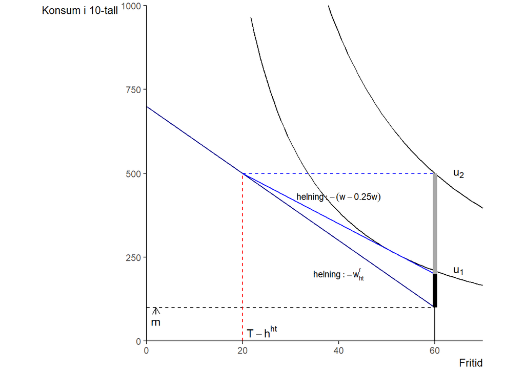

```r
  # Last inn nødvendige biblioteker
  library(ggplot2)
  library(grid)  # For ekstra funksjoner som 'arrow'
  # Definerer budsjettlinjer med og uten skatt
  wr <- function(l_1) {
    return(700 - 10 * l_1)  # Budsjettlinje uten sykepenger
  }
  wrsp_0 <- function(l_1) {
    return(500 - 0*10* l_1)  # Budsjettlinje med 100% sykepenger
  }

  wrsp_1 <- function(l_1) {
    return(650 - 0.75*10* l_1)  # Budsjettlinje med 25% sykepenger
  }
  # Tegner sammenligning av indifferenskurver og budsjettbegrensninger
  figur_3 <- axes_1 +  # Basen av plottet
    stat_function(df,
                 fun=I_0,
                 mapping = aes()
  )+
   # stat_function(df,
    #              fun=I_1,
     #             mapping = aes()
  #  )+
  #  stat_function(df,
 #                 fun=I_2,
 #                 mapping = aes()
 #   )+
    stat_function(df,
                  fun=I_3,
                  mapping = aes()
    )+
    annotate("text",
             x=65,
             y=210,
             label=expression(u[1]))+
    annotate("text",
             x=65,
             y=500,
             label=expression(u[2]))+
    geom_segment(aes(x = 0, y = wr(0), xend = 60, yend = wr(60)), color="darkblue") +  # Tegner budsjettlinje
    annotate("text", x=40,y=200, size = 3,
             label= expression(helning: -w[ht]^{r}))+
  #  geom_segment(aes(x = 20, y = wrsp_0(20), xend = 60, yend = wrsp_0(60)), color="blue") +
    geom_segment(aes(x = 20, y = wrsp_1(20), xend = 60, yend = wrsp_1(60)), color="blue") +
    annotate("text",x=40,y=430, size = 3,
             label= expression(helning: -(w-0.25*w)))+
    geom_segment(aes(x = 20, y = wrsp_0(20), xend = 60, yend = wrsp_0(60)), color="blue", linetype="dashed") +
    geom_segment(aes(x=60, y=0, xend=60, yend=100))+
    geom_segment(aes(x=60, y=100, xend=60, yend=500), color="darkgray", linewidth=2)+
    geom_segment(aes(x=60, y=100, xend=60, yend=200), color="black", linewidth=2)+
    geom_segment(aes(x=0, y=100, xend=60, yend=100), linetype="dashed")+
    annotate("text",x=2,y=60,
             label="m")+
    geom_segment(aes(x=2, y=80, xend=2, yend=100),
                 arrow = arrow(length = unit(0.25, "cm")))+
    geom_segment(aes(x=20, y=0, xend=20, yend=500), linetype="dashed", color="red")+
    annotate("text",x=24,y=30,
             label=expression(T-h^{ht}))
figur_3
```

Vi kan se at når kompensasjonsgraden i det nye sykepengesystemet er blitt redusert til 25 %, vil Gertrud jobbe åtte timer (ca.20% stilling). Hun vil med andre ord ha en gradert sykemelding.Vi ser også at hennes nyttenivå er lavere enn når kompensasjonsgarden var 100 prosent.

En lavere kompensasjonsgrad for sykepenger kan føre til at flere individer velger å jobbe selv når de er syke. Dette kan øke den totale arbeidskraftsdeltakelsen i samfunnet. Det er viktig for beslutningstakere å vurdere både økonomiske og sosiale konsekvenser nøye når de utformer og justerer slike ordninger for å oppnå ønskede målsettinger og samfunnsmessige resultater.